# **Acervo Literário**:

## **análise da minha biblioteca pessoal.**

### Por Luiza Depieri Amorim

Este é um trabalho desenvolvido para o curso de Ciências de Dados I, da [curso-r](http://curso-r.com).

Esse relatório consiste em uma análise da minha biblioteca pessoal, com o objetivo de conhecer mais sobre os livros do meu acervo e traçar meu perfil literário.

Serão considerados, para a análise, os principais gêneros, autores e editoras, a quantidade de livros lidos e aqueles que aguardam pacientemente, pela minha falta de tempo, para serem lidos.

Os livros que fazem parte do meu acervo foram cadastrados em um aplicativo que permite catalogá-los e serviram como base de dados para essa análise.

### **1. Relação entre livros lidos e não lidos**

Entre os momentos de leituras que meu acervo proporcionou, muitas histórias já foram descobertas e tantas outras aguardam por serem exploradas.O gráfico abaixo representa essa relação, ou seja, mostra a quantidade de livros lidos e de livros que ainda não foram lidos no acervo.

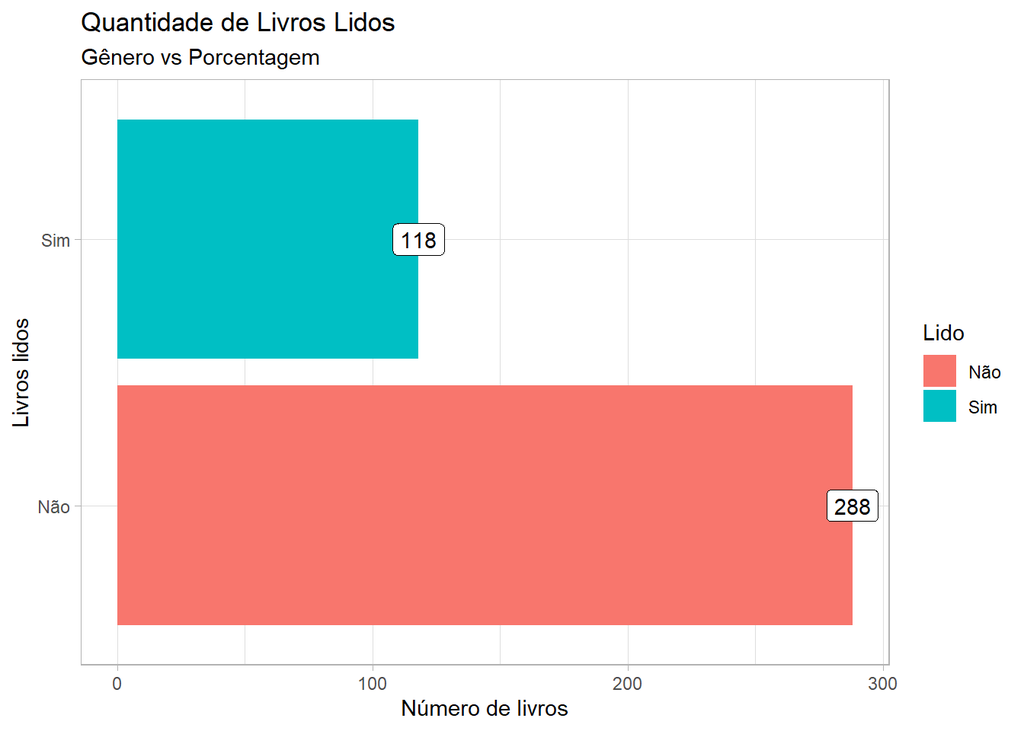

### **2. Gêneros**

Os livros podem, por meio das palavras, proporcionar tantas emoções, experiências e saberes diferentes. Para conhecer melhor, então, a composição literária da minha biblioteca, a tabela apresenta todos os gêneros disponíveis no acervo e a quantidade de livros referente a cada uma dessas categorias.

|  | Categorias | Número de Livros |
| --- | --- | --- |
| 1 | Teoria Literária | 33 |
| 2 | Saúde | 3 |
| 3 | Romance Português | 11 |
| 4 | Romance Policial | 14 |
| 5 | Romance Luso-africano | 18 |
| 6 | Romance Latino-americano | 9 |
| 7 | Romance Estrangeiro | 47 |
| 8 | Romance Brasileiro | 20 |
| 9 | Romance Africano | 11 |
| 10 | Psicanálise | 9 |

[output cut: 24 more lines]

### **3. TOP 5: Principais Gêneros**

Para descobrir quais são os gêneros que não consigo resistir e que sempre me proporcionarão boas leituras, segue o ranking daqueles mais representativos no meu acervo e a porcentagem a que correspondem em relação ao total de livros da minha biblioteca pessoal.

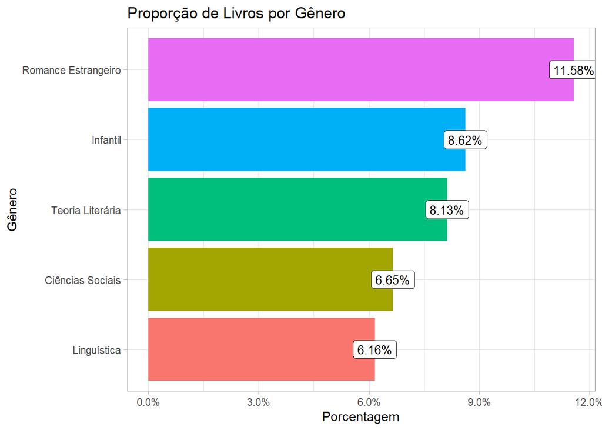

### **4. Autores**

Já entre meus autores preferidos, estão aqueles que representam a maior quantidade de livros no meu acervo, independentemente da categoria de que façam parte. Assim, no gráfico, está a relação entre dos autores mais representativos e a quantidade de livros estão especificados no gráfico.

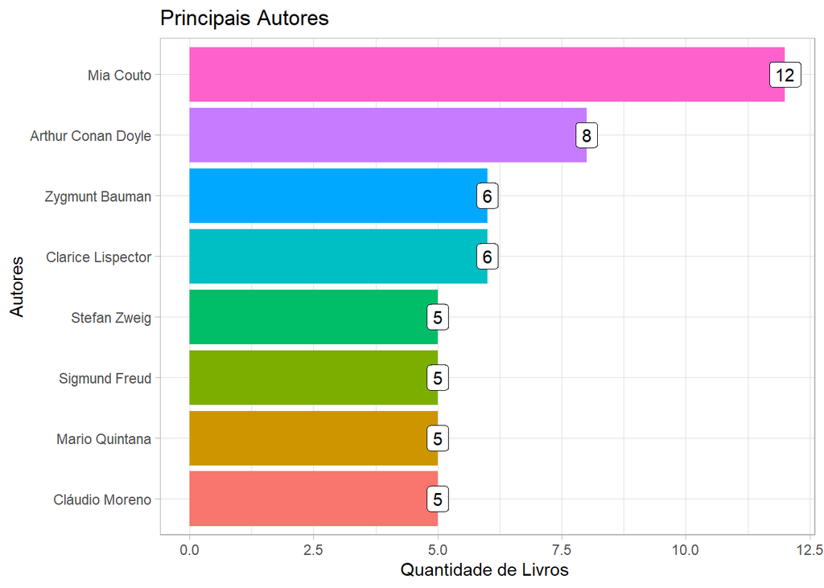

Considerando que o gênero **“Romance Estrangeiro”** foi o mais representativo no acervo, conforme mostrado no gráfico sobre **Proporção de Livros por Gênêro**, segue abaixo a tabela com os principais autores referentes a esse gênero específicamente.

| Principais Autores | Quantidade de Livros |
| --- | --- |
| Friedrich Nietzsche | 2 |
| Rick Riordan | 2 |
| Toni Morrison | 2 |
| William Shakespeare | 2 |

Além disso, ao analisar o principal autor por gênero, os mais numerosos em relação a cada categoria estão representados no gráfico.

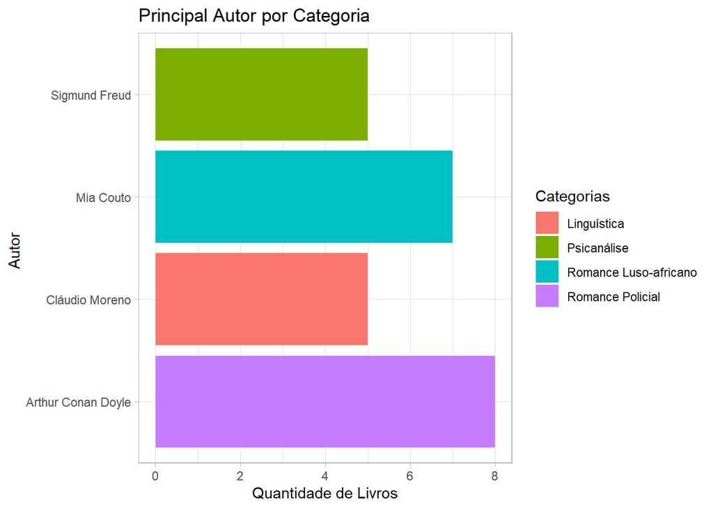

### **5. Editoras**

As editoras que publicam aqueles livros que mais tenho interesse e que, consequentemente, compõem meu acervo estão demostradas abaixo.

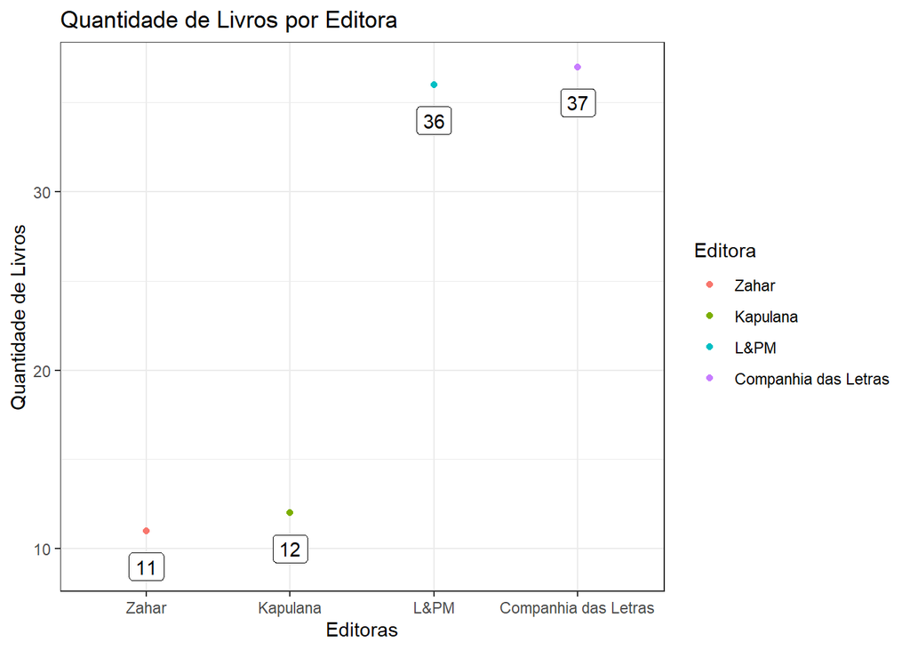

### **6. Perfil Literário**

Sou apaixonada por **Romance Estrangeiro**, e não consigo resistir aos livros de **Friedrich Nietzsche,Rick Riordan, Toni Morrison e William Shakespeare**. Mas definitivamente meu coração bate mais forte pelas obras de **Mia Couto**. Além disso, me identifico com as publicações das editoras **Companhia das Letras e L&PM**. Como admiradora dos livros, gosto de me aventurar em diferentes gêneros, mas tenho meus autores preferidos para cada um deles. Quando quero desvendar um bom mistério (**Romance Policial**), vou de **Arthur Conan Doyle**. Já quando preciso recorrer aos meus estudos sobre Língua Portuguesa(**Linguística**), recorro ao **Cláudio Moreno**. E quando me sinto intrigada a compreender a psiquê humana (**Psicanálise**), desfruto da sabedoria de **Sigmund Freud.**